30 March 2022

# 1 Lesson 1: Importing excel files into R

## 1.1 Learning objectives

1. Import excel files from your computer into R using `readxl::read_excel`

## 1.2 Introduction

When conducting research, you might conduct an experiment and record observations or you may send out questionnaires and record the responses the participants gave.

This data may be stored in different formats, as **.csv (comma separated values)**, **excel files (.xlsx or .xls)**, **SPSS files (.sav)** and **STATA files (.dta)** and many more. R has functionality to work with many different file formats.

### 1.2.1 Reading in data into R

The following phrases mean the same thing- *Read in data/ Load data/ Import data*

Meaning:

When you take a data file that is stored on your local computer and bring it over into R.

This lesson would demonstrate methods used to import excel files stored on your local computer into R using the function `read_excel` from the r package `{readxl}`.

Let’s begin by opening a new script in Rstudio with `File > New File > R Script`

### 1.2.2 Excel files

To import an excel file from your computer into R, you have to know where the file is located.

For example, you want to read into Rstudio an excel file named **excel_data.xlsx** which is saved on your desktop.

First, you are going to create a new object in RStudio. So let’s give it any name. eg.**excel_data**

**`readxl::read_excel()`** is one of the functions to read excel files. Inside the parentheses (…), type the location of the excel file and the file name.

The double colon means that the function on the right comes from the package on the left, so `readxl::read_excel()` refers to the function `read_excel()` in the `{readxl}` package.

**Example**

[figure not shown]

*If the excel file was imported correctly, then the object created “excel_data” should appear under the Environment tab.*

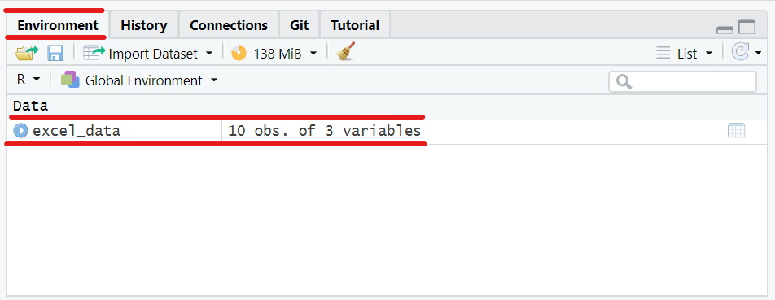

### 1.2.3 Importing excel files using the environment tab in RStudio

Here are the steps to follow.

- Click `Environment > Import > From Excel` .

[figure not shown]

- A new window will pop up. Click on browse to search your computer for the excel file.

[figure not shown]

- Select the appropriate excel file to open.

[figure not shown]

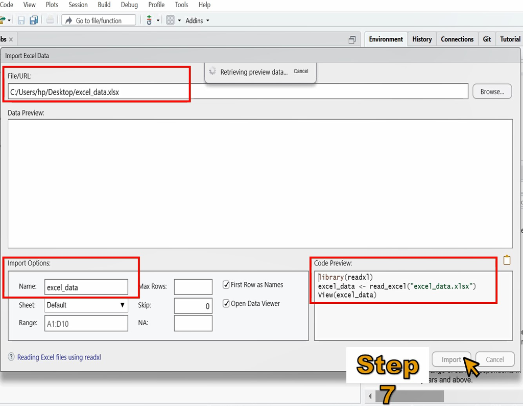

- In the **File/URL box**, you can see the location of the excel file.
- Under **Import Options**, you can change the name of variable that will store your excel file data.
- Under **Code Preview,** you can see the code that was used to import the excel file. Thus, you can type it yourself to read in excel files.

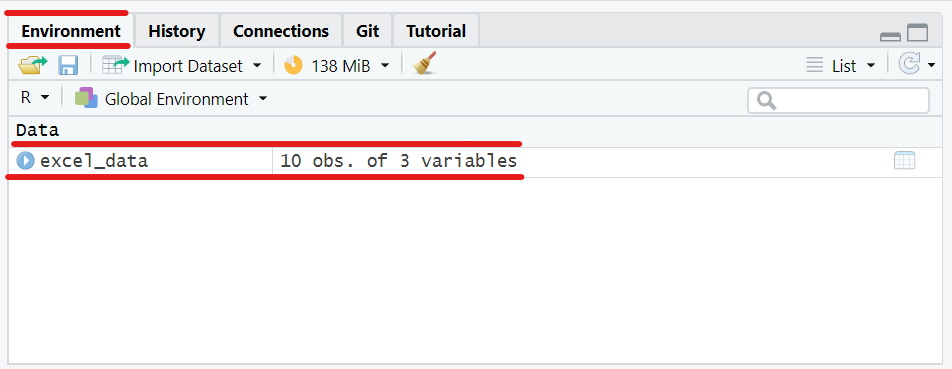

- *Again, if the* *excel file was imported correctly, then the object created “excel_data” should appear under the Environment tab.*

## 1.3 Check the dimensions of your data

A good check to perform after you have imported data into R is to check the dimensions of the data. The dimensions of a data set refer to how many rows and columns are in the data set.

The function `dim()` is already built into R and can be used to find out the number of rows and columns the data set contains.

Here is an example to determine the number of rows and columns in the data set “excel_data” we previously uploaded in R.

[figure not shown]

#### 1.3.0.1 Exercise 1

Which function was introduced in the lesson above to import excel files into R? Store the result in `q1` in a string format meaning your answer should be in quotation marks. Your answer should be in the form “package::function()”

```r
# You can edit this chunk in the the RMarkdown version of this lesson.
# Open the file (01_import_excel_files.Rmd)

q1 <- "YOUR ANSWER HERE"
.check_q1()
```

```
## Wrong. Please try again.
##   1   2
```

#### 1.3.0.2 Exercise 2

Import an excel file into R and assign it to an R object called `my_data`. Use the function `dim()` to check the dimensions of the data set `my_data`.

Store the result in `q2`in a string format meaning your answer should be in quotation marks. Your answer should be in the form “function(data)”

```r
# You can edit this chunk in the the RMarkdown version of this lesson.
# Open the fike (01_import_excel_files.Rmd)

q2 <- "YOUR ANSWER HERE"
.check_q2()
```

```
## Wrong. Please try again.
##   1   2
```

### 1.3.1 Working with different file extensions

Here are some examples of different types of files and the functions used to read them in or write them out. We will go through some of these functions in detail in the upcoming sections.

| Extension | File Type | Reading | Writing |
| --- | --- | --- | --- |
| .csv | Comma-separated values | `readr::read_csv()` | `readr::write_csv()` |
| .tsv, .txt | Tab-separated values | `readr::read_tsv()` | `readr::write_tsv()` |
| .xls, .xlsx | Excel workbook | `readxl::read_excel()` | `rio::export()` |
| .sav | SPSS files | `haven::read_sav()` | `haven::write_sav()` |
| .json | JSON files | `jsonlite::read_json()` | `jsonlite::write_json()` |
| .mat, … | Multiple types | `rio::import()` | `rio::export()` |

# Contributors

The following team members contributed to this lesson:

- [AMA KORANTEMA OWUSU-DARKO](https://thegraphnetwork.training/members/aowusuda/)  
  Data Analyst

  Passionate about equipping health professionals with data analysis skills to promote evidence based research.

# References

Some material in this lesson was adapted from the following sources:

- 2021-10-15, *PsyTeachR, Data Skills for Reproducible Research (v2)* ([link](https://psyteachr.github.io/reprores-v2/data.html))

This work is licensed under the [Creative Commons Attribution Share Alike](https://creativecommons.org/licenses/by-sa/4.0/) license.